[GitHub](https://github.com/Janssena/DeepCompartmentModels.jl)[](https://github.com/Janssena/DeepCompartmentModels.jl/blob/main/tutorials/09-counterfactual.qmd)

# Tutorial 9: Counterfactual Analysis and Bayesian Forecasting

*Continuous predictions, new dosing schedules, and individualising treatment*

## Introduction

A fitted DCM is not just a description of the training data — it is a generative model that can answer clinical "what-if" questions:

- *What concentration–time profile would this patient have on 200 mg instead of 100 mg?*
- *Is once-daily or twice-daily dosing better for achieving the target exposure?*
- *Given two early measurements, what dose should I give next?*

This tutorial covers three closely related workflows:

1. **Continuous predictions** — generating smooth concentration–time curves at any time grid, including between and after observed time points.
2. **Counterfactual dosing** — changing the dosing callback to evaluate alternative treatment schedules.
3. **Bayesian forecasting** — using a population-fitted model as a prior to individualise predictions when only a few observations are available (therapeutic drug monitoring, TDM).

## Setup

```julia
using DeepCompartmentModels
using DataFrames, CSV
using Random
using Statistics: mean
using Accessors
using CairoMakie
```

We reuse the tobramycin model from Tutorial 8. For brevity, the loading and fitting steps are condensed here.

```julia
function load_tobramycin(df, ::Type{T} = Float32) where T
    duration = T(40/60)
    df_group = groupby(df, :ID)
    indvs = Vector{AbstractIndividual}(undef, length(df_group))
    for (i, group) in enumerate(df_group)
        x   = Vector{T}(group[1, [:WT, :AGE, :SEX, :CLCR]])
        obs = group[iszero.(group.EVID), [:TIME, :CP]]
        d   = Matrix{T}(group[group.EVID .== 1, [:TIME, :DOSE]])
        I   = hcat(d, d[:, 2] ./ duration, fill(duration, size(d, 1)))
        cb  = generate_dosing_callback(I, T)
        indvs[i] = Individual(group.ID[1], x, Vector{T}(obs.TIME),
                              Vector{T}(obs.CP), cb, T)
    end
    Population(indvs)
end

df   = DataFrame(CSV.File(joinpath("/home/runner/work/DeepCompartmentModels.jl/DeepCompartmentModels.jl/tutorials", "../data/tobramycin.csv")))
population = load_tobramycin(df)
rng  = Random.Xoshiro(1)

ann = Lux.Chain(
    Normalize([100f0, 90f0, 1f0, 150f0]),
    Lux.Dense(4, 32, tanh),
    Lux.Dense(32, 16, tanh),
    Lux.Dense(16, 4, Lux.softplus),
)
model = DCM(two_comp!, ann, AdditiveError())
obj   = VariationalELBO([1, 2]; path_deriv=true)

ps, st = setup(obj, rng, model, population; init_omega=0.1f0, init_sigma=[0.5f0])
losses = Float32[]
_, ps, st = fit(obj, model, population, Optimisers.Adam(1f-3), ps, st; epochs=1000,
    callback = (e, l) -> begin
        push!(losses, l)
        e % 500 == 0 && println("Epoch $e  -ELBO=$(round(l,digits=2))")
    end)
```

[output not shown]

## Part 1 — Continuous predictions

By default, `predict` returns concentrations only at the individual's observation time points (`get_t(indv)`). Pass a dense `saveat` grid to get a smooth curve at any desired resolution.

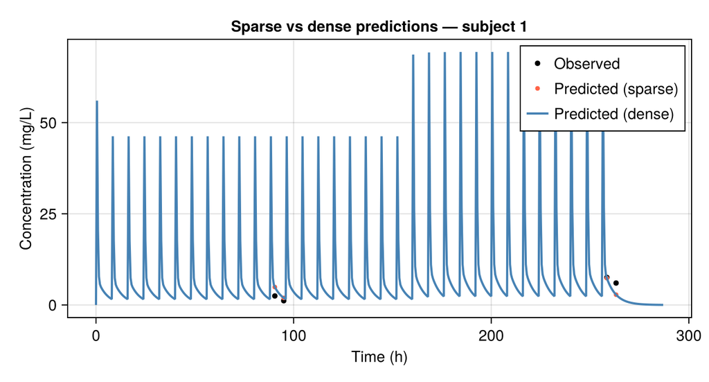

```julia
indv = population[1]

# `ps` holds the random effects of all individuals, `take_batch` selects those of one
ps_indv, st_indv = take_batch(ps, st, [1])

# Sparse: only at observed time points
ŷ_sparse = predict(model, indv, ps_indv, st_indv; saveat=get_t(indv))

# Dense: every 30 minutes
t_dense = Float32.(0:0.5:maximum(get_t(indv)) + 24)
ŷ_dense = predict(model, indv, ps_indv, st_indv; saveat=t_dense)

fig = Figure(size=(650, 350))
ax  = Axis(fig[1,1], xlabel="Time (h)", ylabel="Concentration (mg/L)",
           title="Sparse vs dense predictions — subject $(indv.id)")

scatter!(ax, get_t(indv), get_y(indv); color=:black, markersize=7, label="Observed")
scatter!(ax, get_t(indv), ŷ_sparse;   color=:tomato, markersize=6,  label="Predicted (sparse)")
lines!(ax,   t_dense,     ŷ_dense;    color=:steelblue, linewidth=2, label="Predicted (dense)")

axislegend(ax; position=:rt)
fig
```

Tip

`saveat` can be any `AbstractVector{Float32}` — including grids that extend beyond the last observation. This is essential for predicting accumulation over a multi-day dosing course.

## Part 2 — Counterfactual dosing

To evaluate a different dosing regimen, create a new `DiscreteCallback` with `generate_dosing_callback` and swap it into a copy of the existing individual using `copy(indv, new_callback)`. The individual's covariates and random effects stay the same — only the dosing changes.

### Building a new dosing schedule

```julia
# Helper: build a dosing matrix for repeated IV infusions
# doses: [time, amount] pairs; duration in hours
function iv_regimen(times, amounts, duration::T) where T
    rates = amounts ./ duration
    durs  = fill(T(duration), length(times))
    return hcat(T.(times), T.(amounts), T.(rates), T.(durs))
end
```

```
iv_regimen (generic function with 1 method)
```

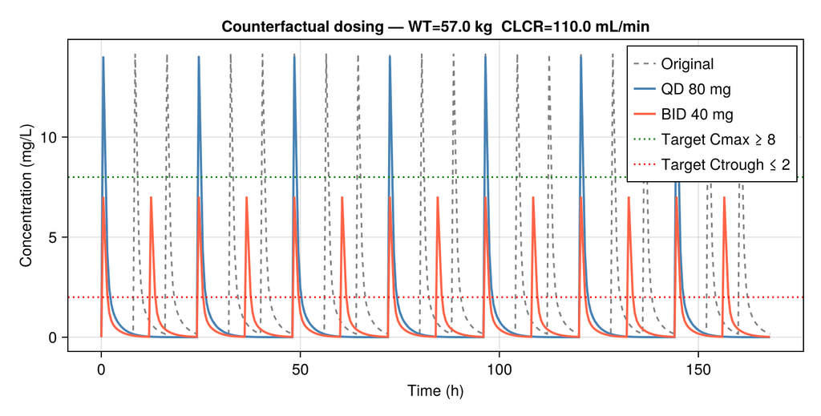

```julia
# Pick a representative subject
subj = population[3]
ps_subj, st_subj = take_batch(ps, st, [3])   # parameters of this subject
x_subj = get_x(subj)   # [WT, AGE, SEX, CLCR]
t_plot  = Float32.(0:0.5:168)   # 7 days

# Original regimen from dataset
pred_orig = predict(model, subj, ps_subj, st_subj; saveat=t_plot)

# Once-daily 80 mg over 40 min (every 24 h)
A_qd  = iv_regimen(0:24:168, fill(80, 8), 40/60)
cb_qd = generate_dosing_callback(A_qd, Float32)

# Twice-daily 40 mg over 40 min (every 12 h)
A_bid  = iv_regimen(0:12:168, fill(40, 15), 40/60)
cb_bid = generate_dosing_callback(A_bid, Float32)

# Swap the callback — all other fields (covariates, random effects) unchanged
subj_qd  = copy(subj, cb_qd)
subj_bid = copy(subj, cb_bid)

pred_qd  = predict(model, subj_qd,  ps_subj, st_subj; saveat=t_plot)
pred_bid = predict(model, subj_bid, ps_subj, st_subj; saveat=t_plot)

fig = Figure(size=(750, 380))
ax  = Axis(fig[1,1],
    xlabel="Time (h)", ylabel="Concentration (mg/L)",
    title="Counterfactual dosing — WT=$(round(x_subj[1],digits=0)) kg  CLCR=$(round(x_subj[4],digits=0)) mL/min")

lines!(ax, t_plot, pred_orig; color=:gray50,    linestyle=:dash, label="Original")
lines!(ax, t_plot, pred_qd;   color=:steelblue, linewidth=2,     label="QD 80 mg")
lines!(ax, t_plot, pred_bid;  color=:tomato,    linewidth=2,     label="BID 40 mg")

# Therapeutic target band (example: 0–2 mg/L trough, >8 mg/L peak)
hlines!(ax, [8f0]; color=:green, linestyle=:dot, label="Target Cmax ≥ 8")
hlines!(ax, [2f0]; color=:red,   linestyle=:dot, label="Target Ctrough ≤ 2")

axislegend(ax; position=:rt)
fig
```

### Population counterfactual: exposure distribution across regimens

Comparing AUC and Cmax distributions across the whole population shows which regimen achieves the best target attainment.

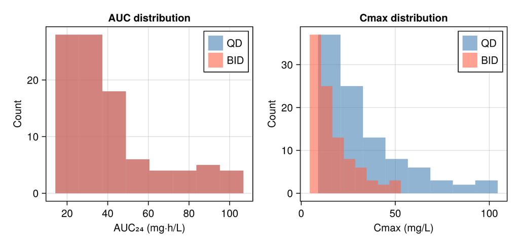

```julia
function auc_and_cmax(pred_vals, t_grid)
    # Trapezoidal AUC over the last 24 h
    last_24 = t_grid .>= (maximum(t_grid) - 24)
    t24 = t_grid[last_24]
    c24 = pred_vals[last_24]
    auc  = sum((c24[1:end-1] .+ c24[2:end]) ./ 2 .* diff(t24))
    cmax = maximum(pred_vals)
    return auc, cmax
end

duration = 40f0/60f0
t_eval   = Float32.(0:0.5:168)

aucs_qd  = Float32[]
aucs_bid = Float32[]
cmaxs_qd  = Float32[]
cmaxs_bid = Float32[]

for (i, subj) in enumerate(population)
    ps_i, st_i = take_batch(ps, st, [i])
    cb_q  = generate_dosing_callback(iv_regimen(0:24:168, fill(80, 8), duration), Float32)
    cb_b  = generate_dosing_callback(iv_regimen(0:12:168, fill(40, 15), duration), Float32)
    ŷ_q   = predict(model, copy(subj, cb_q), ps_i, st_i; saveat=t_eval)
    ŷ_b   = predict(model, copy(subj, cb_b), ps_i, st_i; saveat=t_eval)
    a_q, c_q = auc_and_cmax(ŷ_q, t_eval)
    a_b, c_b = auc_and_cmax(ŷ_b, t_eval)
    push!(aucs_qd,  a_q); push!(cmaxs_qd,  c_q)
    push!(aucs_bid, a_b); push!(cmaxs_bid, c_b)
end

fig = Figure(size=(700, 330))
ax1 = Axis(fig[1,1], xlabel="AUC₂₄ (mg·h/L)", ylabel="Count", title="AUC distribution")
ax2 = Axis(fig[1,2], xlabel="Cmax (mg/L)",     ylabel="Count", title="Cmax distribution")

hist!(ax1, aucs_qd;   bins=8, color=(:steelblue, 0.6), label="QD")
hist!(ax1, aucs_bid;  bins=8, color=(:tomato,    0.6), label="BID")
hist!(ax2, cmaxs_qd;  bins=8, color=(:steelblue, 0.6), label="QD")
hist!(ax2, cmaxs_bid; bins=8, color=(:tomato,    0.6), label="BID")

for ax in [ax1, ax2]; axislegend(ax; position=:rt); end
fig
```

## Part 3 — Bayesian forecasting (TDM)

In therapeutic drug monitoring, a new patient arrives with known covariates and one or two measured concentrations. The goal is to update our prediction of their PK parameters and recommend an appropriate dose.

With `VariationalELBO`, the fitted `ps.theta` (neural network) and `ps.omega` (prior on random effects) encode population knowledge. For a new patient, we only need to find their individual random effects φᵢ = (μᵢ, Lᵢ).

### Step 1 — Create a new patient

```julia
# New patient: 68-year-old, 75 kg male, CLCR = 55 mL/min
# Received 80 mg IV over 40 min, two early samples taken
x_new  = Float32[75f0, 68f0, 1f0, 55f0]   # WT, AGE, SEX, CLCR
t_tdm  = Float32[2.0, 6.0]                  # blood draw times (h)
y_tdm  = Float32[5.8, 3.1]                  # measured concentrations (mg/L)

A_new  = iv_regimen([0], [80], 40/60)
cb_new = generate_dosing_callback(A_new, Float32)

new_patient = Individual("TDM-001", x_new, t_tdm, y_tdm, cb_new, Float32)
new_pop     = Population([new_patient])
```

```
1-element Population{BasicIndividual{Float32}}:
 BasicIndividual{Float32}(id = TDM-001, ...)
```

### Step 2 — Initialise individual posterior from the population prior

We add a fresh variational posterior for the new patient, initialised from the learned prior Ω. `setup` creates parameters for the new population; we only keep its `phi` (μ = 0, covariance scaled from Ω) and combine it with the trained θ and Ω.

```julia
# Fresh phi for the new patient, with the variances of the learned Ω
ω² = [ps.omega[i, i] for i in 1:size(ps.omega, 1)]
ps_new, st_new = setup(obj, rng, model, new_pop; init_omega = ω², init_sigma = [0.5f0])

# Build full ps for the new patient: keep population theta/error/omega, fresh phi
ps_tdm = (
    theta = ps.theta,
    error = ps.error,
    omega = ps.omega,
    phi   = ps_new.phi,
)
st_tdm = (
    theta = st.theta,
    phi   = st_new.phi,
)
```

```
(theta = (layer_1 = (lb = Float32[0.0, 0.0, 0.0, 0.0], ub = Float32[100.0, 90.0, 1.0, 150.0]), layer_2 = NamedTuple(), layer_3 = NamedTuple(), layer_4 = NamedTuple()), phi = (mask = Float32[1.0 0.0; 0.0 1.0; 0.0 0.0; 0.0 0.0], epsilon = Vector{Float32}[[-1.5326439, -0.6409679]]))
```

### Step 3 — Optimise only φᵢ, keeping θ and Ω fixed

```julia
function fit_individual_phi(obj, model, indv_pop, ps, st; epochs=400, lr=5f-3)
    opt_phi = Optimisers.setup(Optimisers.Adam(lr), ps.phi)
    for epoch in 1:epochs
        # Update epsilon samples (reparameterisation noise)
        st = update_state(st, obj, model, indv_pop, ps)

        # Gradient of the negative ELBO (with the path derivative estimator, since `obj` uses it)
        loss, ∇ = value_and_gradient(obj, model, indv_pop, ps, st)
        opt_phi, new_phi = Optimisers.update(opt_phi, ps.phi, ∇.phi)
        ps = @set ps.phi = new_phi
    end
    return ps, st
end

ps_tdm, st_tdm = fit_individual_phi(obj, model, new_pop, ps_tdm, st_tdm)
println("Posterior μ: $(round.(ps_tdm.phi.μ[1], digits=3))")
```

```
Posterior μ: Float32[-0.478, -0.025]
```

### Step 4 — Compare prior vs posterior prediction

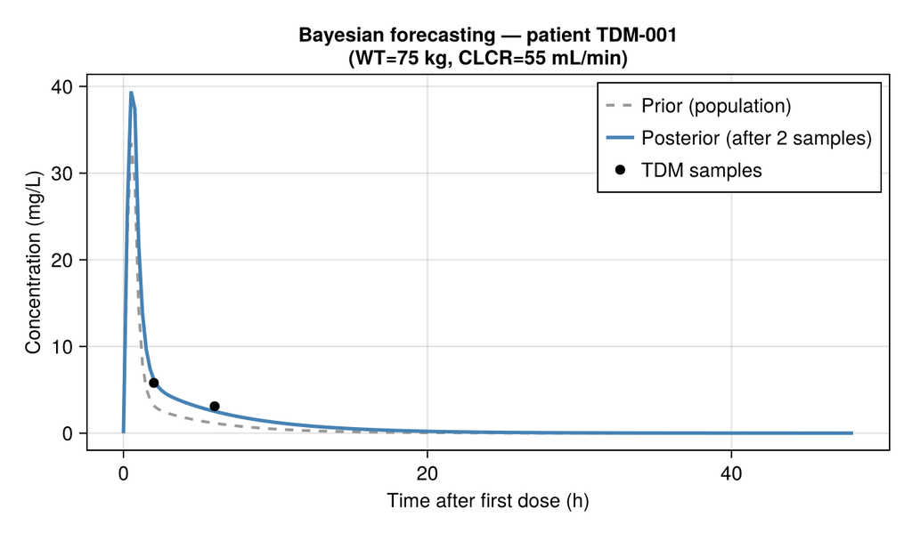

```julia
t_forecast = Float32.(0:0.25:48)

# Prior: μᵢ = 0 (population mean, no individual data)
ps_prior = @set ps_tdm.phi.μ[1] = zeros(Float32, 2)
ŷ_prior  = predict(model, new_patient, ps_prior, st_tdm; saveat=t_forecast)

# Posterior: μᵢ updated from two TDM observations
ŷ_post   = predict(model, new_patient, ps_tdm, st_tdm; saveat=t_forecast)

fig = Figure(size=(650, 380))
ax  = Axis(fig[1,1],
    xlabel="Time after first dose (h)", ylabel="Concentration (mg/L)",
    title="Bayesian forecasting — patient TDM-001\n(WT=75 kg, CLCR=55 mL/min)")

lines!(ax, t_forecast, ŷ_prior; color=:gray60, linestyle=:dash, linewidth=2,
       label="Prior (population)")
lines!(ax, t_forecast, ŷ_post;  color=:steelblue, linewidth=2.5,
       label="Posterior (after 2 samples)")
scatter!(ax, t_tdm, y_tdm; color=:black, markersize=10, label="TDM samples")

axislegend(ax; position=:rt)
fig
```

### Step 5 — Dose recommendation

Given the posterior prediction, we can find the dose that achieves a target AUC:

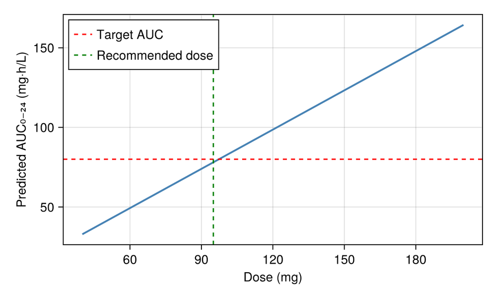

```julia
# Target AUC₀₋₂₄ = 80 mg·h/L (a typical aminoglycoside PK/PD target)
target_auc = 80f0
t_24 = Float32.(0:0.5:24)

function predicted_auc(dose, new_patient, ps, st, duration=40f0/60f0)
    A_d  = iv_regimen([0], [dose], duration)
    cb_d = generate_dosing_callback(A_d, Float32)
    ŷ_d  = predict(model, copy(new_patient, cb_d), ps, st; saveat=t_24)
    return sum((ŷ_d[1:end-1] .+ ŷ_d[2:end]) ./ 2 .* diff(t_24))
end

# Grid search over doses (in practice, a proper optimiser would be used)
dose_range = Float32.(40:5:200)
aucs_pred  = [predicted_auc(d, new_patient, ps_tdm, st_tdm) for d in dose_range]

optimal_dose = dose_range[argmin(abs.(aucs_pred .- target_auc))]
println("Recommended dose to achieve AUC = $target_auc mg·h/L: $(optimal_dose) mg")

fig = Figure(size=(550, 330))
ax  = Axis(fig[1,1], xlabel="Dose (mg)", ylabel="Predicted AUC₀₋₂₄ (mg·h/L)")
lines!(ax, dose_range, aucs_pred; color=:steelblue, linewidth=2)
hlines!(ax, [target_auc]; color=:red, linestyle=:dash, label="Target AUC")
vlines!(ax, [optimal_dose]; color=:green, linestyle=:dash, label="Recommended dose")
axislegend(ax; position=:lt)
fig
```

## Summary

| Task | Key function / pattern |
| --- | --- |
| Smooth prediction curve | `predict(model, indv, ps_indv, st_indv; saveat=dense_grid)`, with `ps_indv, st_indv = take_batch(ps, st, [i])` |
| New dosing regimen | `generate_dosing_callback(new_matrix, T)` |
| Counterfactual individual | `copy(indv, new_callback)` |
| Bayesian forecasting | `fit_individual_phi` — optimise `ps.phi` with frozen `ps.theta` |
| Dose optimisation | Grid-search or optimiser over `predicted_auc(dose, ...)` |